# DAT301_Project 2

Retail Sales Analysis (Project 2 - DAT 301) Anand Chamoli October 9, 2025

This project analyzes the Sample Superstore dataset to uncover insights into sales performance, profitability, and customer behavior across product categories and regions. Using Python, I applied data cleaning, transformation, exploratory analysis, and visualization techniques to answer key business questions.

What are we researching?

1. Which product categories and subcategories drive the most sales and profit?
2. How do sales vary by region and state?
3. Are there seasonal or monthly sales fluctuations?
4. Which customer segments generate the most revenue?
5. How do discounts affect profit margins?

```python
import pandas as pd
import numpy as np
import matplotlib.pyplot as plt
import seaborn as sns
from matplotlib.ticker import FuncFormatter

%matplotlib inline

pd.set_option('display.max_columns', 20)
plt.style.use('seaborn-v0_8')
```

```python
df = pd.read_csv("/Users/anandchamoli/Desktop/DATA SCIENCE 2026/DAT 301/Superstore.csv", encoding='latin1')
print("Shape:", df.shape)
df.head(5)
```

```
Shape: (9994, 21)
```

|  | Row ID | Order ID | Order Date | Ship Date | Ship Mode | Customer ID | Customer Name | Segment | Country | City | ... | Postal Code | Region | Product ID | Category | Sub-Category | Product Name | Sales | Quantity | Discount | Profit |
| --- | --- | --- | --- | --- | --- | --- | --- | --- | --- | --- | --- | --- | --- | --- | --- | --- | --- | --- | --- | --- | --- |
| 0 | 1 | CA-2016-152156 | 11/8/2016 | 11/11/2016 | Second Class | CG-12520 | Claire Gute | Consumer | United States | Henderson | ... | 42420 | South | FUR-BO-10001798 | Furniture | Bookcases | Bush Somerset Collection Bookcase | 261.9600 | 2 | 0.00 | 41.9136 |
| 1 | 2 | CA-2016-152156 | 11/8/2016 | 11/11/2016 | Second Class | CG-12520 | Claire Gute | Consumer | United States | Henderson | ... | 42420 | South | FUR-CH-10000454 | Furniture | Chairs | Hon Deluxe Fabric Upholstered Stacking Chairs,... | 731.9400 | 3 | 0.00 | 219.5820 |
| 2 | 3 | CA-2016-138688 | 6/12/2016 | 6/16/2016 | Second Class | DV-13045 | Darrin Van Huff | Corporate | United States | Los Angeles | ... | 90036 | West | OFF-LA-10000240 | Office Supplies | Labels | Self-Adhesive Address Labels for Typewriters b... | 14.6200 | 2 | 0.00 | 6.8714 |
| 3 | 4 | US-2015-108966 | 10/11/2015 | 10/18/2015 | Standard Class | SO-20335 | Sean O'Donnell | Consumer | United States | Fort Lauderdale | ... | 33311 | South | FUR-TA-10000577 | Furniture | Tables | Bretford CR4500 Series Slim Rectangular Table | 957.5775 | 5 | 0.45 | -383.0310 |
| 4 | 5 | US-2015-108966 | 10/11/2015 | 10/18/2015 | Standard Class | SO-20335 | Sean O'Donnell | Consumer | United States | Fort Lauderdale | ... | 33311 | South | OFF-ST-10000760 | Office Supplies | Storage | Eldon Fold 'N Roll Cart System | 22.3680 | 2 | 0.20 | 2.5164 |

5 rows × 21 columns

Data Cleaning Summary:

```python
df.info()
df.isna().sum()
```

```
<class 'pandas.core.frame.DataFrame'>
RangeIndex: 9994 entries, 0 to 9993
Data columns (total 21 columns):
 #   Column         Non-Null Count  Dtype
---  ------         --------------  -----
 0   Row ID         9994 non-null   int64
 1   Order ID       9994 non-null   object
 2   Order Date     9994 non-null   object
 3   Ship Date      9994 non-null   object
 4   Ship Mode      9994 non-null   object
 5   Customer ID    9994 non-null   object
 6   Customer Name  9994 non-null   object
 7   Segment        9994 non-null   object
 8   Country        9994 non-null   object
 9   City           9994 non-null   object
 10  State          9994 non-null   object
 11  Postal Code    9994 non-null   int64
 12  Region         9994 non-null   object
 13  Product ID     9994 non-null   object
 14  Category       9994 non-null   object
 15  Sub-Category   9994 non-null   object
 16  Product Name   9994 non-null   object
 17  Sales          9994 non-null   float64
 18  Quantity       9994 non-null   int64
 19  Discount       9994 non-null   float64
 20  Profit         9994 non-null   float64
dtypes: float64(3), int64(3), object(15)
memory usage: 1.6+ MB
```

```
Row ID           0
Order ID         0
Order Date       0
Ship Date        0
Ship Mode        0
Customer ID      0
Customer Name    0
Segment          0
Country          0
City             0
State            0
Postal Code      0
Region           0
Product ID       0
Category         0
Sub-Category     0
Product Name     0
Sales            0
Quantity         0
Discount         0
Profit           0
dtype: int64
```

```python
df = df.drop_duplicates() #Removing duplicates

# Converting Date columns to Datetime

df['Order Date'] = pd.to_datetime(df['Order Date'])
df['Ship Date'] = pd.to_datetime(df['Ship Date'])

# Add year, month, and week columns

df['Year'] = df['Order Date'].dt.year
df['Month'] = df['Order Date'].dt.month_name()
df['Month_Num'] = df['Order Date'].dt.month

monthly_sales = df.groupby(['Year', 'Month'])['Sales'].sum().reset_index()
monthly_sales

# Checking for negative or invalid values

print("Any negative sales?", (df['Sales'] < 0).any())
df.head(1)
```

```
Any negative sales? False
```

|  | Row ID | Order ID | Order Date | Ship Date | Ship Mode | Customer ID | Customer Name | Segment | Country | City | ... | Category | Sub-Category | Product Name | Sales | Quantity | Discount | Profit | Year | Month | Month_Num |
| --- | --- | --- | --- | --- | --- | --- | --- | --- | --- | --- | --- | --- | --- | --- | --- | --- | --- | --- | --- | --- | --- |
| 0 | 1 | CA-2016-152156 | 2016-11-08 | 2016-11-11 | Second Class | CG-12520 | Claire Gute | Consumer | United States | Henderson | ... | Furniture | Bookcases | Bush Somerset Collection Bookcase | 261.96 | 2 | 0.0 | 41.9136 | 2016 | November | 11 |

1 rows × 24 columns

```python
df.describe(include='all').T
```

|  | count | unique | top | freq | mean | std | min | 25% | 50% | 75% | max |
| --- | --- | --- | --- | --- | --- | --- | --- | --- | --- | --- | --- |
| Row ID | 9994.0 | NaN | NaN | NaN | 4997.5 | 2885.163629 | 1.0 | 2499.25 | 4997.5 | 7495.75 | 9994.0 |
| Order ID | 9994 | 5009 | CA-2017-100111 | 14 | NaN | NaN | NaN | NaN | NaN | NaN | NaN |
| Order Date | 9994 | 1237 | 9/5/2016 | 38 | NaN | NaN | NaN | NaN | NaN | NaN | NaN |
| Ship Date | 9994 | 1334 | 12/16/2015 | 35 | NaN | NaN | NaN | NaN | NaN | NaN | NaN |
| Ship Mode | 9994 | 4 | Standard Class | 5968 | NaN | NaN | NaN | NaN | NaN | NaN | NaN |
| Customer ID | 9994 | 793 | WB-21850 | 37 | NaN | NaN | NaN | NaN | NaN | NaN | NaN |
| Customer Name | 9994 | 793 | William Brown | 37 | NaN | NaN | NaN | NaN | NaN | NaN | NaN |
| Segment | 9994 | 3 | Consumer | 5191 | NaN | NaN | NaN | NaN | NaN | NaN | NaN |
| Country | 9994 | 1 | United States | 9994 | NaN | NaN | NaN | NaN | NaN | NaN | NaN |
| City | 9994 | 531 | New York City | 915 | NaN | NaN | NaN | NaN | NaN | NaN | NaN |
| State | 9994 | 49 | California | 2001 | NaN | NaN | NaN | NaN | NaN | NaN | NaN |
| Postal Code | 9994.0 | NaN | NaN | NaN | 55190.379428 | 32063.69335 | 1040.0 | 23223.0 | 56430.5 | 90008.0 | 99301.0 |
| Region | 9994 | 4 | West | 3203 | NaN | NaN | NaN | NaN | NaN | NaN | NaN |
| Product ID | 9994 | 1862 | OFF-PA-10001970 | 19 | NaN | NaN | NaN | NaN | NaN | NaN | NaN |
| Category | 9994 | 3 | Office Supplies | 6026 | NaN | NaN | NaN | NaN | NaN | NaN | NaN |
| Sub-Category | 9994 | 17 | Binders | 1523 | NaN | NaN | NaN | NaN | NaN | NaN | NaN |
| Product Name | 9994 | 1850 | Staple envelope | 48 | NaN | NaN | NaN | NaN | NaN | NaN | NaN |
| Sales | 9994.0 | NaN | NaN | NaN | 229.858001 | 623.245101 | 0.444 | 17.28 | 54.49 | 209.94 | 22638.48 |
| Quantity | 9994.0 | NaN | NaN | NaN | 3.789574 | 2.22511 | 1.0 | 2.0 | 3.0 | 5.0 | 14.0 |
| Discount | 9994.0 | NaN | NaN | NaN | 0.156203 | 0.206452 | 0.0 | 0.0 | 0.2 | 0.2 | 0.8 |
| Profit | 9994.0 | NaN | NaN | NaN | 28.656896 | 234.260108 | -6599.978 | 1.72875 | 8.6665 | 29.364 | 8399.976 |

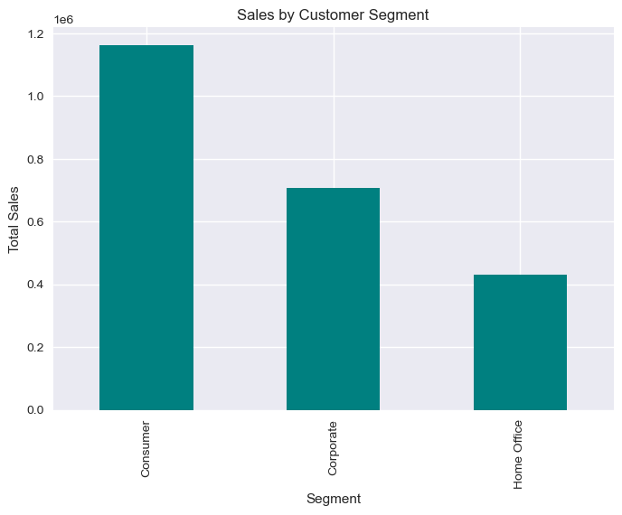

```python
segment_sales = df.groupby('Segment')['Sales'].sum().sort_values(ascending=False)
segment_sales.plot(kind='bar', color='teal', title='Sales by Customer Segment')
plt.xlabel('Segment')
plt.ylabel('Total Sales')
plt.show()
```

Customer Segment Analysis: Consumer and Corporate segments dominate total sales, while Home Office accounts for the smallest share.

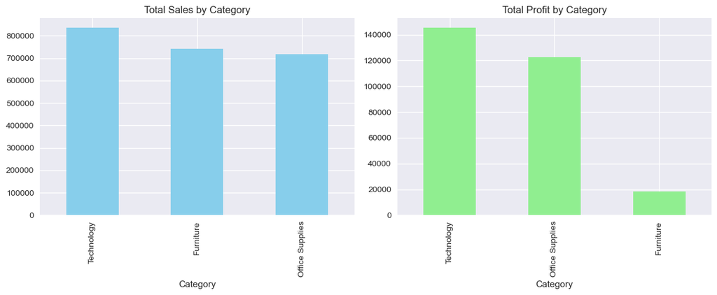

```python
cat_sales = df.groupby('Category')['Sales'].sum().sort_values(ascending=False)
cat_profit = df.groupby('Category')['Profit'].sum().sort_values(ascending=False)

fig, ax = plt.subplots(1,2, figsize=(12,5))
cat_sales.plot(kind='bar', ax=ax[0], color='skyblue', title='Total Sales by Category')
cat_profit.plot(kind='bar', ax=ax[1], color='lightgreen', title='Total Profit by Category')
plt.tight_layout()
plt.show()
```

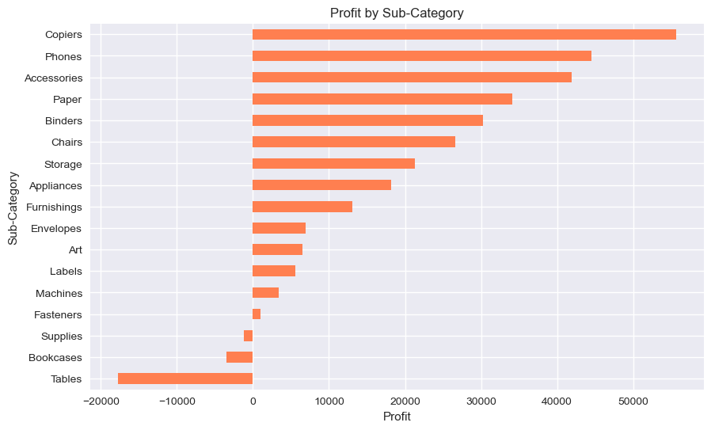

```python
subcat_profit = df.groupby('Sub-Category')['Profit'].sum().sort_values()
plt.figure(figsize=(10,6))
subcat_profit.plot(kind='barh', color='coral')
plt.title("Profit by Sub-Category")
plt.xlabel("Profit")
plt.ylabel("Sub-Category")
plt.show()
```

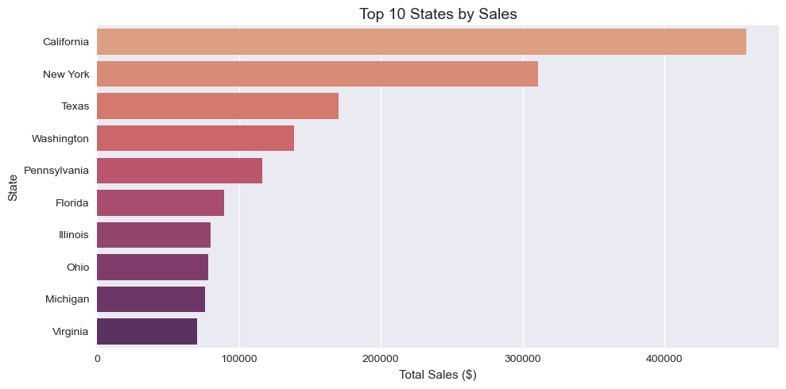

|  | State | Sales |
| --- | --- | --- |
| 0 | California | 457687.6315 |
| 1 | New York | 310876.2710 |
| 2 | Texas | 170188.0458 |
| 3 | Washington | 138641.2700 |
| 4 | Pennsylvania | 116511.9140 |
| 5 | Florida | 89473.7080 |
| 6 | Illinois | 80166.1010 |
| 7 | Ohio | 78258.1360 |
| 8 | Michigan | 76269.6140 |
| 9 | Virginia | 70636.7200 |

```python
state_sales = df.groupby('State')['Sales'].sum().sort_values(ascending=False).head(10).reset_index()

plt.figure(figsize=(10,5))
sns.barplot(data=state_sales, x='Sales', y='State', hue='State', palette='flare', legend=False)
plt.title("Top 10 States by Sales", fontsize=14)
plt.xlabel("Total Sales ($)")
plt.ylabel("State")
plt.tight_layout()
plt.show()

state_sales
```

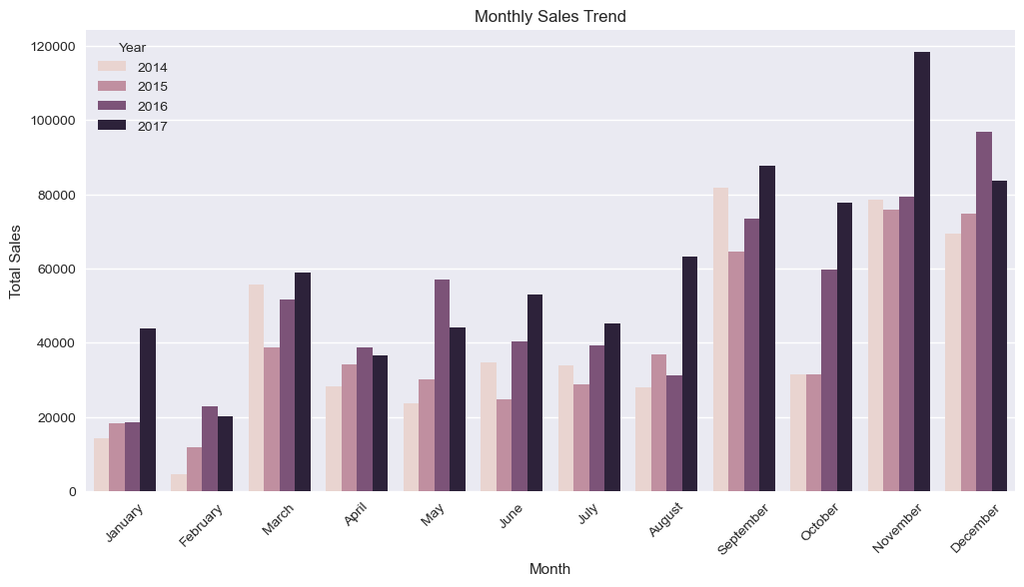

```python
import matplotlib.pyplot as plt
import seaborn as sns

month_order = ['January', 'February', 'March', 'April', 'May', 'June',
               'July', 'August', 'September', 'October', 'November', 'December']

plt.figure(figsize = (12,6))
sns.barplot(data = monthly_sales, x ='Month', y ='Sales', hue ='Year', order = month_order)
plt.title("Monthly Sales Trend")
plt.xlabel("Month")
plt.ylabel("Total Sales")
plt.xticks(rotation = 45)
plt.show()
```

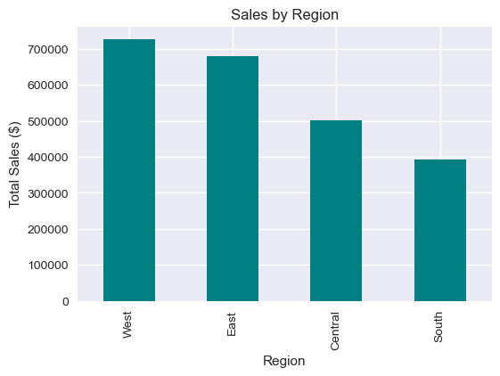

```python
region_sales = df.groupby('Region')['Sales'].sum().sort_values(ascending=False)
plt.figure(figsize=(6,4))
region_sales.plot(kind='bar', color='teal')
plt.title("Sales by Region")
plt.ylabel("Total Sales ($)")
plt.show()
```

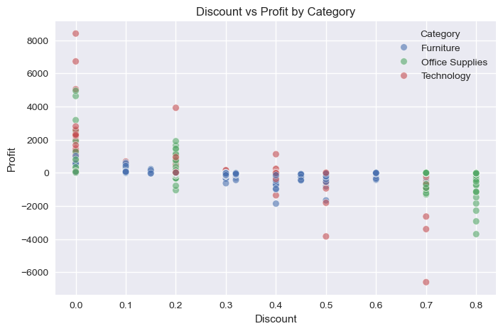

```python
plt.figure(figsize=(8,5))
sns.scatterplot(data=df, x='Discount', y='Profit', hue='Category', alpha=0.6)
plt.title("Discount vs Profit by Category")
plt.show()
```

Profit Vs Discount Analysis: High discount levels correlate with reduced profits, indicating that excessive discounting hurts margins.

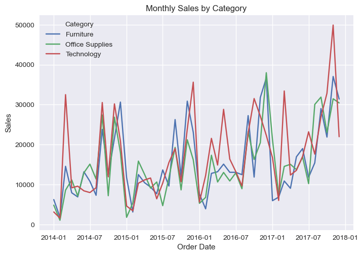

```python
monthly = df.groupby([df['Order Date'].dt.to_period('M'), 'Category'])['Sales'].sum().reset_index()
monthly['Order Date'] = monthly['Order Date'].dt.to_timestamp()
sns.lineplot(x='Order Date', y='Sales', hue='Category', data=monthly)
plt.title('Monthly Sales by Category')
plt.show()
```

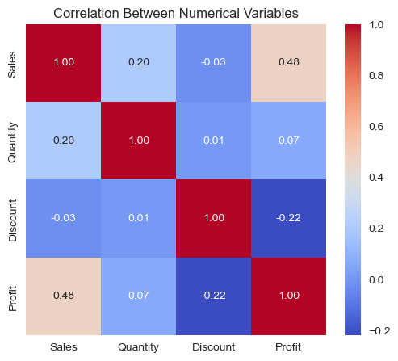

```python
plt.figure(figsize=(6,5))
sns.heatmap(df[['Sales','Quantity','Discount','Profit']].corr(), annot=True, cmap='coolwarm', fmt=".2f")
plt.title("Correlation Between Numerical Variables")
plt.show()
```

This analysis provides a clear overview of the Sample Superstore’s sales performance. Leveraging these insights can help optimize discount strategies, improve regional targeting, and enhance overall profitability.

References

- Vivek468, “Sample - Superstore Dataset (Final)”, Kaggle, 2019.  
  https://www.kaggle.com/datasets/vivek468/superstore-dataset-final
- Python libraries: pandas, matplotlib, seaborn (documentation).